# Project: Cardiac death mortality on breast cancer patients (Dr. C Sanchez)

Edwin Navarro - BBC Biostatistician

2024-06-19

### **I. Research Objective:**

#### A. Datasets (available at the moment):

Cancer Registry Data: The initial selection is all women residents in PR diagnosed with breast cancer (by microscopic confirmation) during the period 2005-2019.

#### B. Analysis Proposal:

Below is the overall proposed analysis strategy to meet the study objectives:

1. Descriptive characteristics of the study population
2. Estimate Standardized Mortality Ratios (SMR’s) with confidence intervals (Poisson-based CI’s) on the study population. Proposed SMR definition: observed number of CVD deaths among breast cancer patients divided by the expected number of CVD deaths in the matched general female population in PR.
3. Estimate Cumulative Incidence of Death (Cumulative Mortality) considering the effects of competing risks (Cardiac-related death vs Other/Breast Cancer-related death).

### **II. Descriptive Analysis**

#### A. Summary Counts

*Table 1: Baseline Characteristics of Study Population*

|  | Total (N = 27238) | Alive (N=18943) | Cardiac Death (N=537) | Breast Cancer Death (N=4595) | Other Cause Death (N=3163) |
| --- | --- | --- | --- | --- | --- |
| **Treatment** |  |  |  |  |  |
| Surgery + Chemotherapy + Radiotherapy | 6139(22.54%) | 4372(23.08%) | 74(13.78%) | 1168(25.42%) | 525(16.6%) |
| Surgery + Radiotherapy | 5811(21.33%) | 4648(24.54%) | 97(18.06%) | 426(9.27%) | 640(20.23%) |
| Surgery + Chemotherapy | 3273(12.02%) | 2271(11.99%) | 35(6.52%) | 723(15.73%) | 244(7.71%) |
| Chemotherapy + Radiotherapy | 139(0.51%) | 41(0.22%) | 1(0.19%) | 79(1.72%) | 18(0.57%) |
| Surgery Only | 9177(33.69%) | 6312(33.32%) | 272(50.65%) | 1277(27.79%) | 1316(41.61%) |
| Chemotherapy Only | 477(1.75%) | 198(1.05%) | 6(1.12%) | 206(4.48%) | 67(2.12%) |
| Radiotheraphy Only | 70(0.26%) | 21(0.11%) | 2(0.37%) | 34(0.74%) | 13(0.41%) |
| No treatment | 972(3.57%) | 425(2.24%) | 26(4.84%) | 362(7.88%) | 159(5.03%) |
| Unknown | 1180(4.33%) | 655(3.46%) | 24(4.47%) | 320(6.96%) | 181(5.72%) |
| **Stage at Diagnosis** |  |  |  |  |  |
| Localized | 15520(56.98%) | 12298(64.92%) | 322(59.96%) | 1225(26.66%) | 1675(52.96%) |
| Distant | 1389(5.1%) | 361(1.91%) | 15(2.79%) | 801(17.43%) | 212(6.7%) |
| Regional | 8727(32.04%) | 5297(27.96%) | 165(30.73%) | 2215(48.2%) | 1050(33.2%) |
| Unstaged | 1602(5.88%) | 987(5.21%) | 35(6.52%) | 354(7.7%) | 226(7.15%) |
| **Age at Diagnosis** |  |  |  |  |  |
| 0-17 | 0(0%) | 0(0%) | 0(0%) | 0(0%) | 0(0%) |
| 18-59 | 11989(44.02%) | 9184(48.48%) | 57(10.61%) | 2079(45.24%) | 669(21.15%) |
| 60+ | 15243(55.96%) | 9753(51.49%) | 480(89.39%) | 2516(54.76%) | 2494(78.85%) |
| Unknown | 6(0.02%) | 6(0.03%) | 0(0%) | 0(0%) | 0(0%) |
| **ER Assay** |  |  |  |  |  |
| Positive | 15994(58.72%) | 12198(64.39%) | 279(51.96%) | 2002(43.57%) | 1515(47.9%) |
| Negative | 4102(15.06%) | 2549(13.46%) | 55(10.24%) | 1069(23.26%) | 429(13.56%) |
| Other | 2234(8.2%) | 1320(6.97%) | 68(12.66%) | 457(9.95%) | 389(12.3%) |
| Unknown | 4908(18.02%) | 2876(15.18%) | 135(25.14%) | 1067(23.22%) | 830(26.24%) |
| **PR Assay** |  |  |  |  |  |
| Positive | 13612(49.97%) | 10532(55.6%) | 239(44.51%) | 1530(33.3%) | 1311(41.45%) |
| Negative | 6325(23.22%) | 4125(21.78%) | 90(16.76%) | 1504(32.73%) | 606(19.16%) |
| Other | 2282(8.38%) | 1343(7.09%) | 69(12.85%) | 472(10.27%) | 398(12.58%) |
| Unknown | 5019(18.43%) | 2943(15.54%) | 139(25.88%) | 1089(23.7%) | 848(26.81%) |
| **HER2** |  |  |  |  |  |
| Positive | 2445(8.98%) | 1814(9.58%) | 20(3.72%) | 447(9.73%) | 164(5.18%) |
| Negative | 12916(47.42%) | 10053(53.07%) | 186(34.64%) | 1633(35.54%) | 1044(33.01%) |
| Other | 9407(34.54%) | 5371(28.35%) | 290(54%) | 2085(45.38%) | 1661(52.51%) |
| Unknown | 2470(9.07%) | 1705(9%) | 41(7.64%) | 430(9.36%) | 294(9.29%) |
| **Comorbidities** |  |  |  |  |  |
| 3 or more comorbidites | 126(0.46%) | 57(0.3%) | 12(2.23%) | 21(0.46%) | 36(1.14%) |
| 1-2 comorbidities | 3110(11.42%) | 2185(11.53%) | 83(15.46%) | 431(9.38%) | 411(12.99%) |
| No comorbidity | 24002(88.12%) | 16701(88.16%) | 442(82.31%) | 4143(90.16%) | 2716(85.87%) |
| **Myocardial Infarction** |  |  |  |  |  |
| Yes | 53(0.19%) | 23(0.12%) | 10(1.86%) | 7(0.15%) | 13(0.41%) |
| No | 17536(64.38%) | 13089(69.1%) | 266(49.53%) | 2600(56.58%) | 1581(49.98%) |
| Unknown | 9649(35.42%) | 5831(30.78%) | 261(48.6%) | 1988(43.26%) | 1569(49.6%) |
| **Congestive heart failure** |  |  |  |  |  |
| Yes | 371(1.36%) | 213(1.12%) | 31(5.77%) | 55(1.2%) | 72(2.28%) |
| No | 17218(63.21%) | 12899(68.09%) | 245(45.62%) | 2552(55.54%) | 1522(48.12%) |
| Unknown | 9649(35.42%) | 5831(30.78%) | 261(48.6%) | 1988(43.26%) | 1569(49.6%) |
| **Peripheral vascular disease** |  |  |  |  |  |
| Yes | 506(1.86%) | 340(1.79%) | 16(2.98%) | 70(1.52%) | 80(2.53%) |
| No | 17083(62.72%) | 12772(67.42%) | 260(48.42%) | 2537(55.21%) | 1514(47.87%) |
| Unknown | 9649(35.42%) | 5831(30.78%) | 261(48.6%) | 1988(43.26%) | 1569(49.6%) |
| **Cerebrovascular disease** |  |  |  |  |  |
| Yes | 273(1%) | 159(0.84%) | 12(2.23%) | 41(0.89%) | 61(1.93%) |
| No | 17316(63.57%) | 12953(68.38%) | 264(49.16%) | 2566(55.84%) | 1533(48.47%) |
| Unknown | 9649(35.42%) | 5831(30.78%) | 261(48.6%) | 1988(43.26%) | 1569(49.6%) |
| **Chronic pulmonary disease** |  |  |  |  |  |
| Yes | 1015(3.73%) | 685(3.62%) | 33(6.15%) | 142(3.09%) | 155(4.9%) |
| No | 16574(60.85%) | 12427(65.6%) | 243(45.25%) | 2465(53.65%) | 1439(45.49%) |
| Unknown | 9649(35.42%) | 5831(30.78%) | 261(48.6%) | 1988(43.26%) | 1569(49.6%) |
| **Diabetes without chronic complication** |  |  |  |  |  |
| Yes | 1787(6.56%) | 1251(6.6%) | 47(8.75%) | 254(5.53%) | 235(7.43%) |
| No | 14744(54.13%) | 11151(58.87%) | 190(35.38%) | 2219(48.29%) | 1184(37.43%) |
| Unknown | 10707(39.31%) | 6541(34.53%) | 300(55.87%) | 2122(46.18%) | 1744(55.14%) |
| **Diabetes with chronic complication** |  |  |  |  |  |
| Yes | 28(0.1%) | 12(0.06%) | 2(0.37%) | 9(0.2%) | 5(0.16%) |
| No | 17561(64.47%) | 13100(69.15%) | 274(51.02%) | 2598(56.54%) | 1589(50.24%) |
| Unknown | 9649(35.42%) | 5831(30.78%) | 261(48.6%) | 1988(43.26%) | 1569(49.6%) |
| **Health Region** |  |  |  |  |  |
| NORESTE METRO | 6633(24.35%) | 4538(23.96%) | 142(26.44%) | 1173(25.53%) | 780(24.66%) |
| CENTRAL BAYAMON | 4341(15.94%) | 3087(16.3%) | 70(13.04%) | 677(14.73%) | 507(16.03%) |
| OESTE AGUADILLA/MAYAGUEZ | 3892(14.29%) | 2656(14.02%) | 82(15.27%) | 684(14.89%) | 470(14.86%) |
| SURESTE CAGUAS | 3922(14.4%) | 2788(14.72%) | 66(12.29%) | 629(13.69%) | 439(13.88%) |
| SUR PONCE | 3840(14.1%) | 2591(13.68%) | 88(16.39%) | 740(16.1%) | 421(13.31%) |
| NORTE ARECIBO | 3389(12.44%) | 2405(12.7%) | 67(12.48%) | 506(11.01%) | 411(12.99%) |
| ESTE FAJARDO | 1047(3.84%) | 710(3.75%) | 22(4.1%) | 184(4%) | 131(4.14%) |
| COUNTY UNKNOWN | 174(0.64%) | 168(0.89%) | 0(0%) | 2(0.04%) | 4(0.13%) |

Note: Values are N (%), unless otherwise indicated.

*Table 2: Summary statistics by mortality type*

|  | Breast Cancer Death (N=4595) | Cardiac Death (N=537) | Other Cause Death (N=3163) |
| --- | --- | --- | --- |
| **Age at Diagnosis** |  |  |  |
| Average | 61.23(±14.61) | 73.69(±11.34) | 69.68(±13.09) |
| Median | 61(51-72) | 75(67-82) | 71(62-80) |
| Range | 18-103 | 35-101 | 23-104 |
| **Age at Death** |  |  |  |
| Average | 64.92(±14.54) | 79.29(±11.75) | 75.22(±13.58) |
| Median | 65(55-75) | 81(72-88) | 77(67-85) |
| Range | 21-104 | 41-103 | 24-107 |
| **Time to death (years)** |  |  |  |
| Average | 3.68(±3.31) | 5.6(±3.98) | 5.54(±4.1) |
| Median | 3(1-5) | 5(2-8) | 5(2-8) |
| Range | 0-17 | 0-17 | 0-18 |

#### B. Exploratory Data Analysis

*Figure: Age distribution of study population*

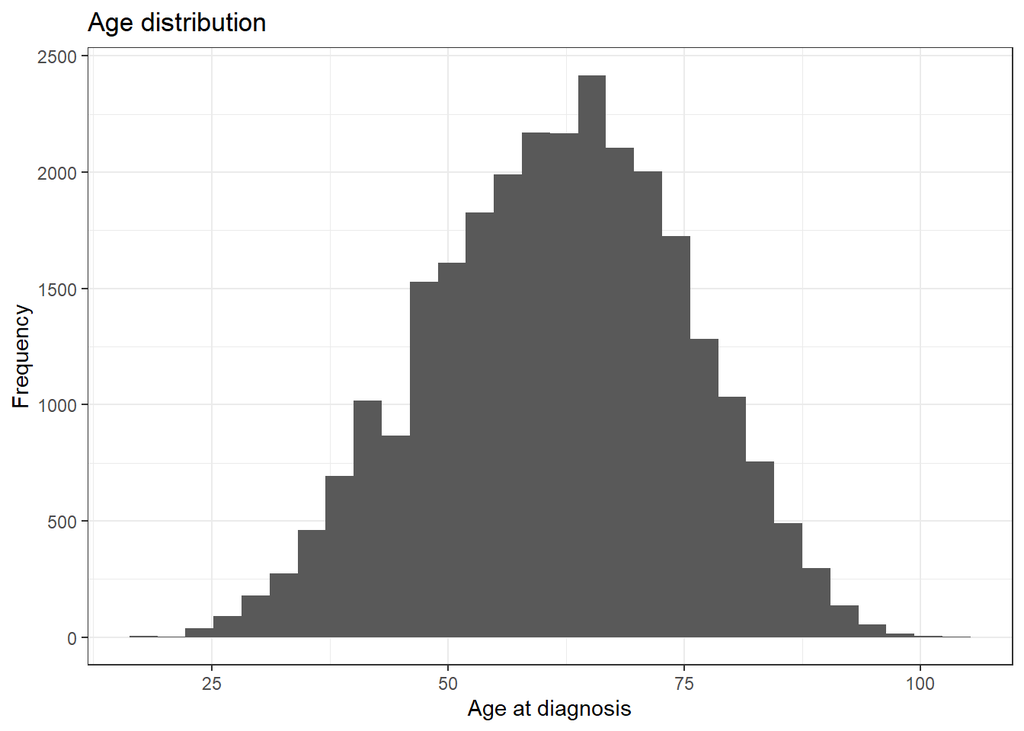

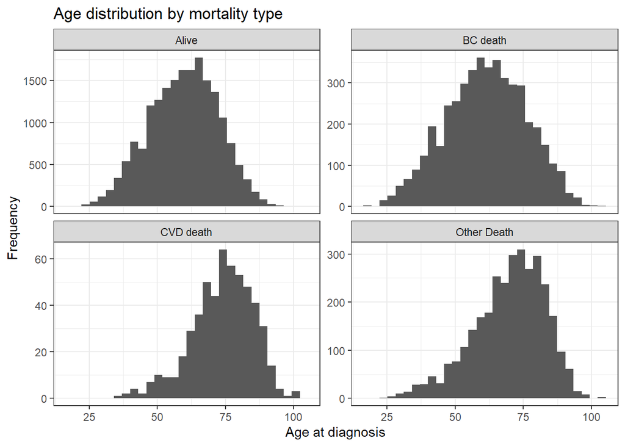

*Figure: Bar plots for procedures (surgery,chemotherapy,radiotherapy)*

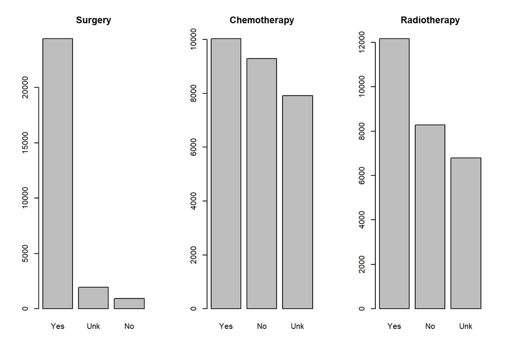

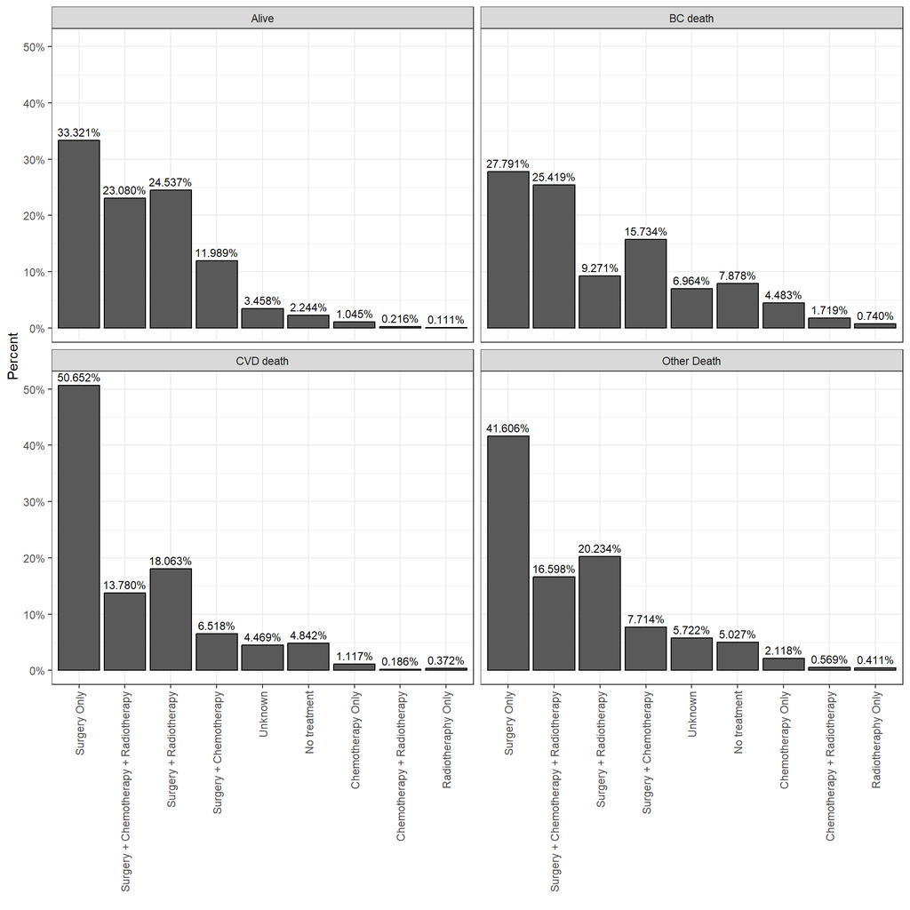

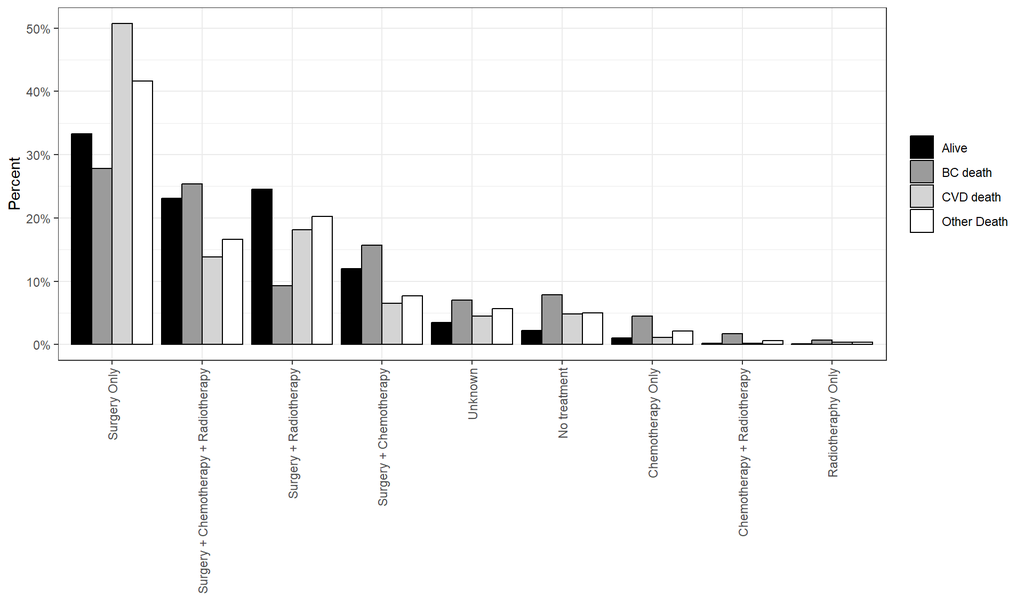

*Figure: Bar plot for Comorbidity Index*

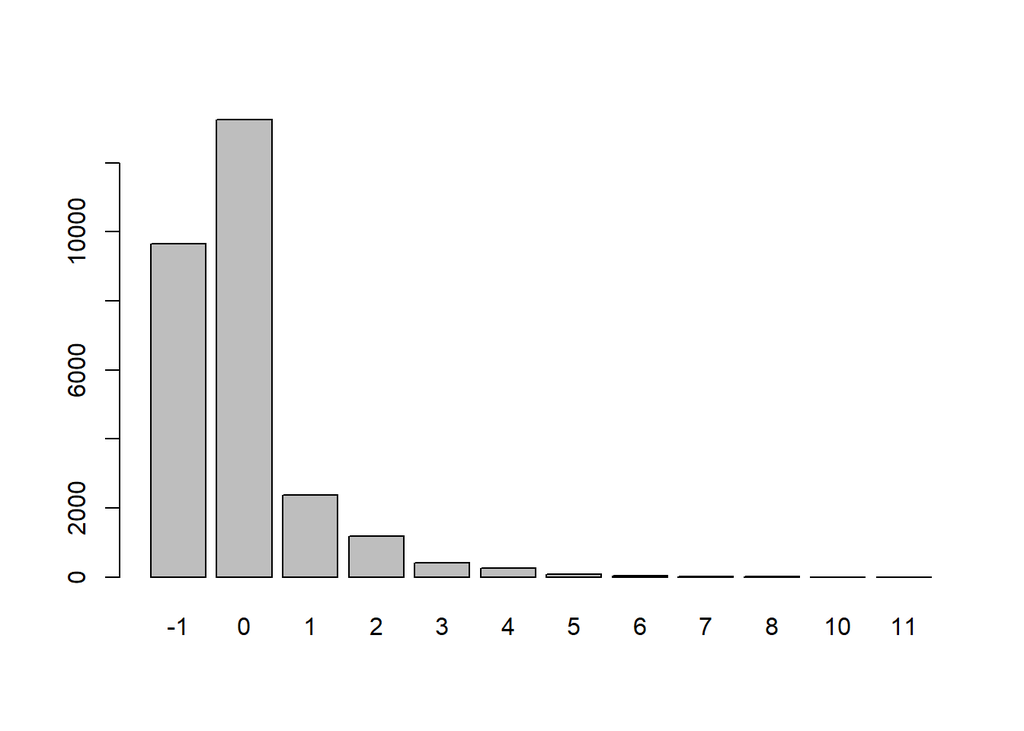

*Figure: Bar plots for ER, PR & HER2*

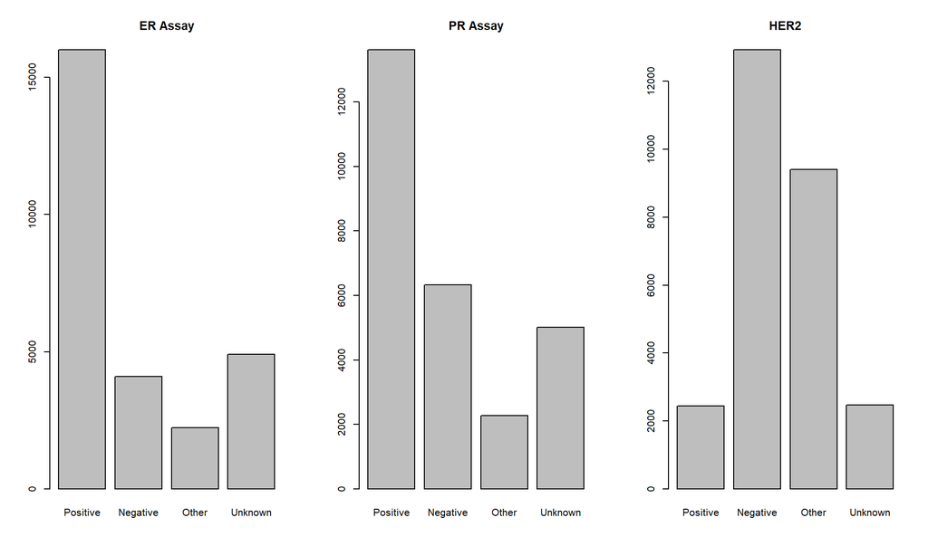

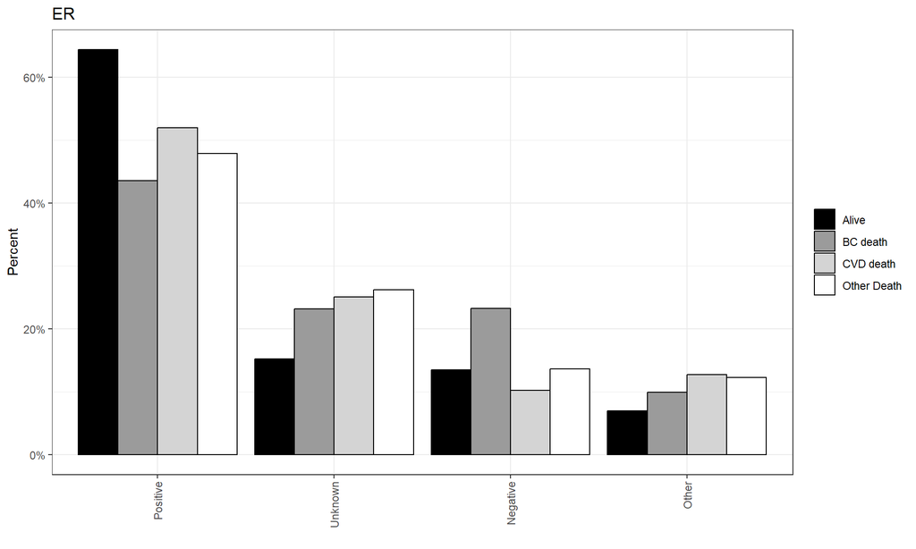

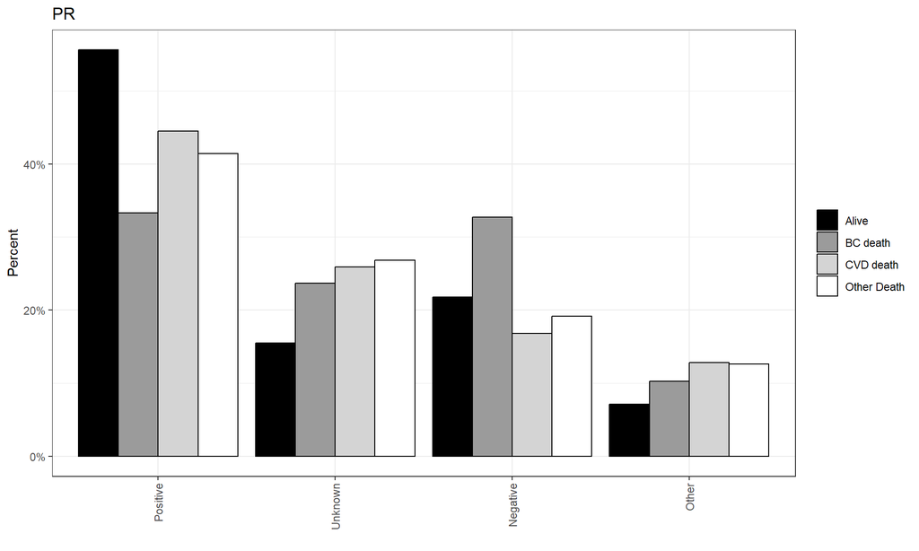

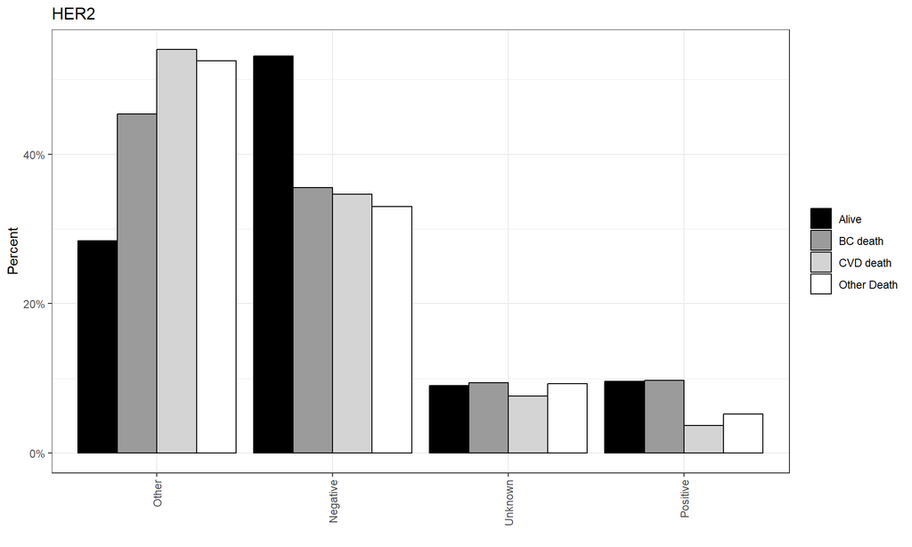

### **III. All Cause Mortality**

*Figure 1: All Cause Mortality Survival Curve*

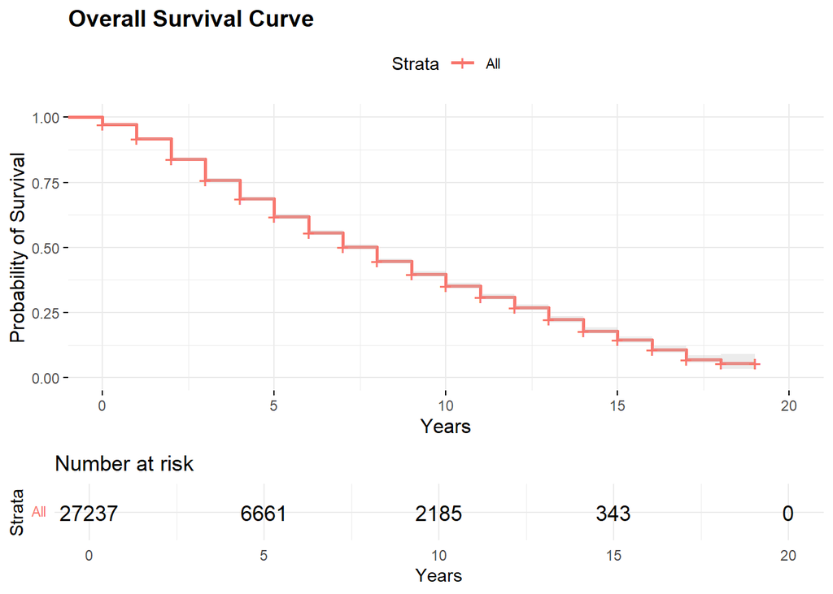

| 5-year (95% CI) | 10-year (95% CI) | 15-year (95% CI) |
| --- | --- | --- |
| 61.85(61.01-62.72) | 35.3(34.25-36.37) | 14.54(13.39-15.8) |

Values are n (%), unless otherwise indicated. Crude number and rate estimates of mortality from the study data. All-cause mortality estimated by Kaplan-Meier methods

*Figure 2: All Cause Mortality Survival Curve by Treatment*

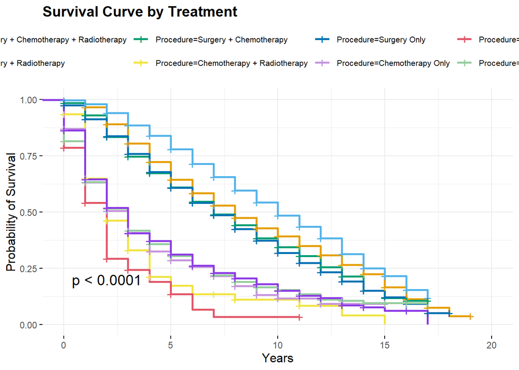

| Treatment | 5-year (95% CI) | 10-year (95% CI) | 15-year (95% CI) |
| --- | --- | --- | --- |
| Surgery + Chemotherapy + Radiotherapy | 64.39(62.66-66.16) | 39.32(37.14-41.63) | 16.57(14-19.61) |
| Surgery + Radiotherapy | 77.95(76.23-79.71) | 48.56(46.05-51.2) | 21.54(18.72-24.79) |
| Surgery + Chemotherapy | 61.03(58.67-63.49) | 34.44(31.38-37.8) | 11.91(8.6-16.48) |
| Chemotherapy + Radiotherapy | 17.36(10.78-27.96) | 0 | 0(0-0) |
| Surgery Only | 60.79(59.31-62.3) | 31.95(30.25-33.75) | 12.28(10.55-14.29) |
| Chemotherapy Only | 28.56(23.67-34.46) | 11.61(7.57-17.8) | 9.29(5.03-17.13) |
| Radiotheraphy Only | 13.57(6.28-29.34) | 0 | 0 |
| No treatment | 30.55(26.96-34.62) | 15.46(12.36-19.32) | 9.62(6.6-14.02) |
| Unknown | 31.17(27.36-35.51) | 15.15(11.79-19.47) | 6.15(3.18-11.92) |

Values are n (%), unless otherwise indicated. Crude number and rate estimates of mortality from the study data. All-cause mortality estimated by Kaplan-Meier methods

### **IV. Competing Risks**

If the goal is to assess cardiac death mortality, both death related to breast cancer and other causes are competing events.

*Figure 1.A: Cumulative incidence functions (1 = Cardiac death ; 2 = Other cause death)*

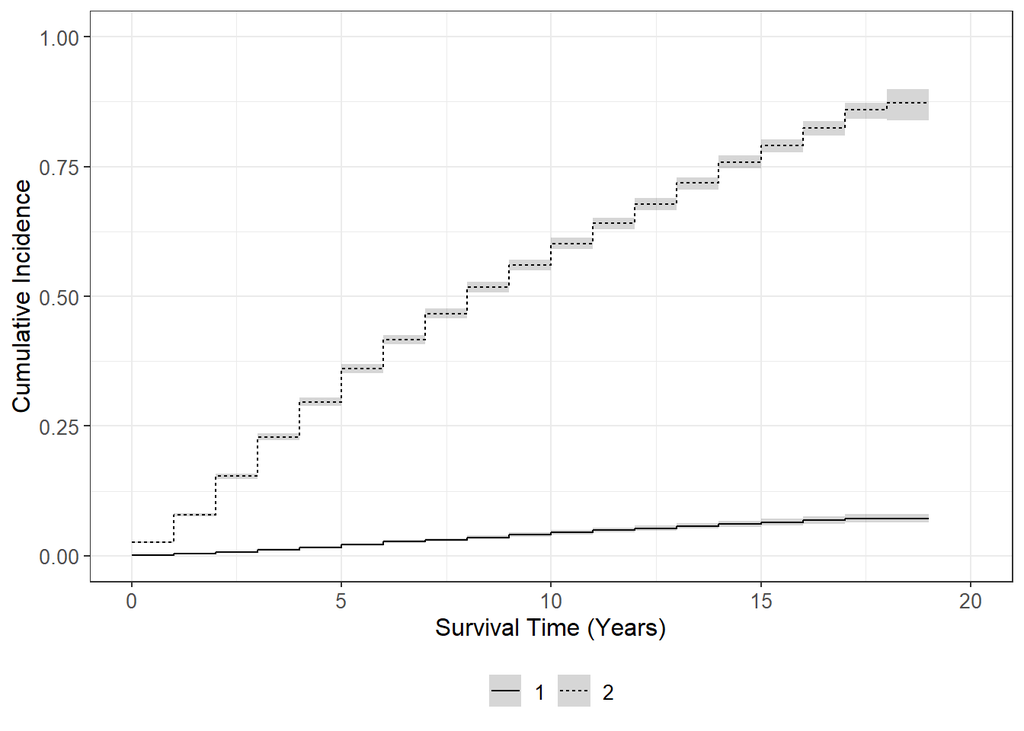

*Table: Cumulative Incidence of Death (CVD Death vs Other)*

|  | 5-year (95% CI) | 10-year (95% CI) | 15-year (95% CI) |
| --- | --- | --- | --- |
| CVD Death | 2.11(1.87-2.37) | 4.52(4.1-4.97) | 6.48(5.85-7.14) |
| Other Cause Death | 36.03(35.19-36.87) | 60.19(59.12-61.24) | 78.98(77.68-80.21) |

Note: Values are n (%), unless otherwise indicated. CVD and BC mortality are estimated by Fine and Gray’s competing risk method.

*Figure 1.B: Cumulative incidence functions (1 = Cardiac death ; 2 = Breast Cancer death, 3 = Other Cause death)*

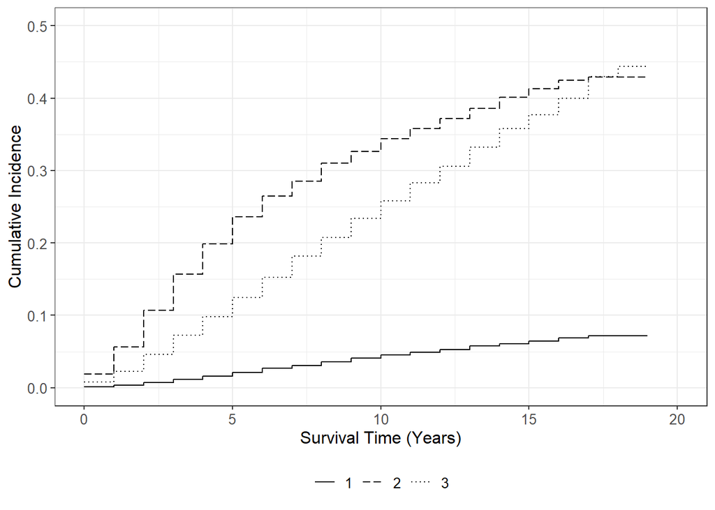

*Table: Cumulative Incidence of Death (including BC mortality)*

|  | 5-year (95% CI) | 10-year (95% CI) | 15-year (95% CI) |
| --- | --- | --- | --- |
| CVD Death | 2.11(1.87-2.37) | 4.52(4.1-4.97) | 6.48(5.85-7.14) |
| BC Death | 23.6(22.87-24.32) | 34.39(33.46-35.33) | 41.27(40.08-42.46) |
| Other Cause Death | 12.44(11.87-13.02) | 25.79(24.88-26.71) | 37.71(36.42-38.99) |

Note: Values are n (%), unless otherwise indicated. CVD, BC mortality and Other Cause mortality are estimated by Fine and Gray’s competing risk method.

#### **IV. Cumulative Incidence Curves for CVD Mortality**

*Figure 1.B: Cumulative incidence curves for CVD Mortality*

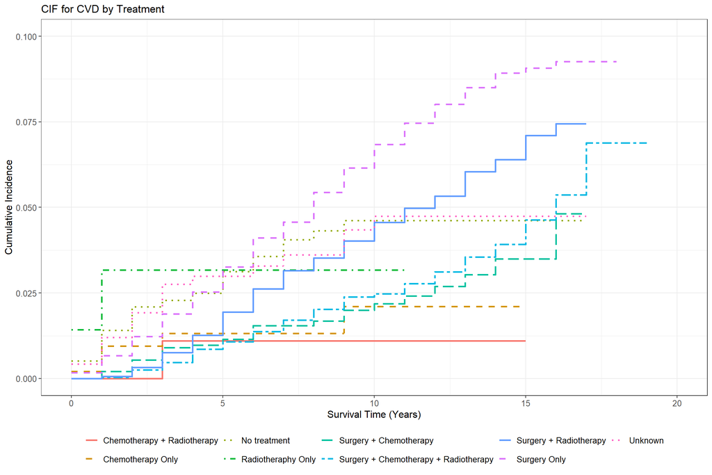

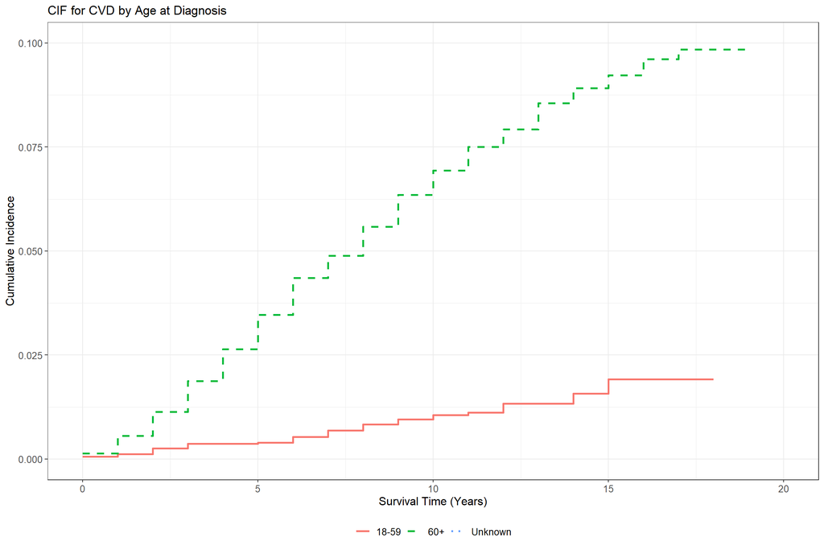

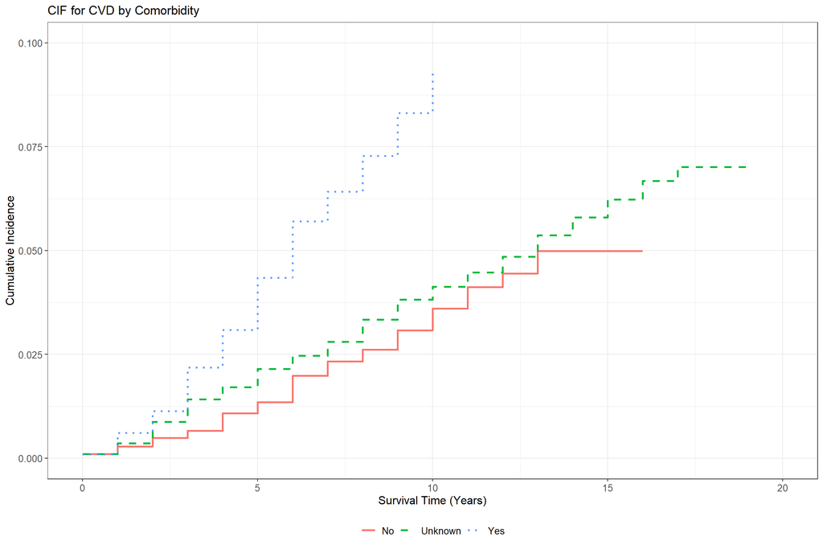

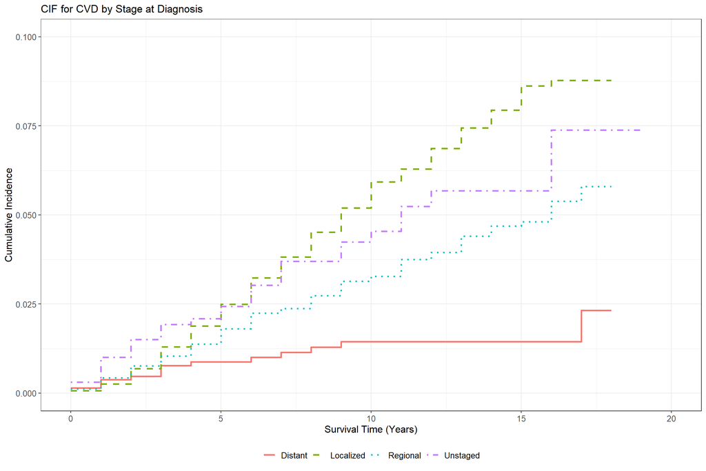

#### A. Competing Risks Regression

##### 1. Subdistribution of Harzards

*Table : Hazard ratios (and 95% Confidence Intervals) from Subdistribution Hazard Model for Cardiac Death*

| **Characteristic** | **HR**<sup>1</sup> | **95% CI**<sup>1</sup> | **p-value** |
| --- | --- | --- | --- |
| StageAtDx |  |  |  |
| Localized | — | — |  |
| Distant | 0.38 | 0.22, 0.65 | <0.001 |
| Regional | 0.80 | 0.66, 0.97 | 0.024 |
| Unstaged | 0.87 | 0.60, 1.28 | 0.5 |
| Comorb.cat |  |  |  |
| Yes | — | — |  |
| No | 0.42 | 0.33, 0.54 | <0.001 |
| Unknown | 0.64 | 0.52, 0.79 | <0.001 |
| Procedure |  |  |  |
| Surgery + Chemotherapy + Radiotherapy | — | — |  |
| Surgery + Radiotherapy | 1.41 | 1.04, 1.90 | 0.028 |
| Surgery + Chemotherapy | 0.94 | 0.63, 1.40 | 0.8 |
| Chemotherapy + Radiotherapy | 0.69 | 0.10, 4.94 | 0.7 |
| Surgery Only | 2.39 | 1.84, 3.10 | <0.001 |
| Chemotherapy Only | 1.14 | 0.49, 2.63 | 0.8 |
| Radiotheraphy Only | 3.24 | 0.74, 14.2 | 0.12 |
| No treatment | 2.13 | 1.33, 3.42 | 0.002 |
| Unknown | 2.06 | 1.25, 3.38 | 0.004 |

<sup>1</sup> HR = Hazard Ratio, CI = Confidence Interval

#### Forest Plot of Hazard Ratios

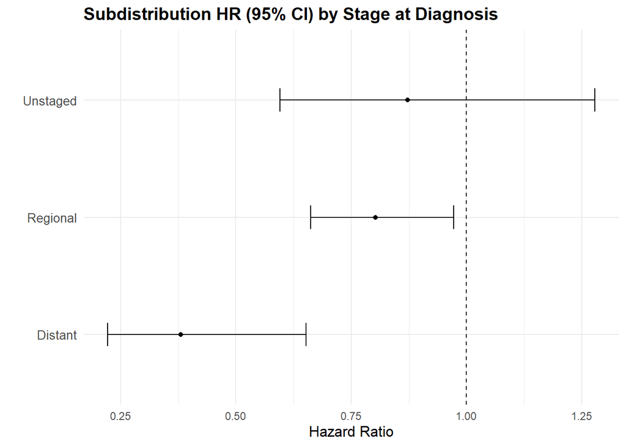

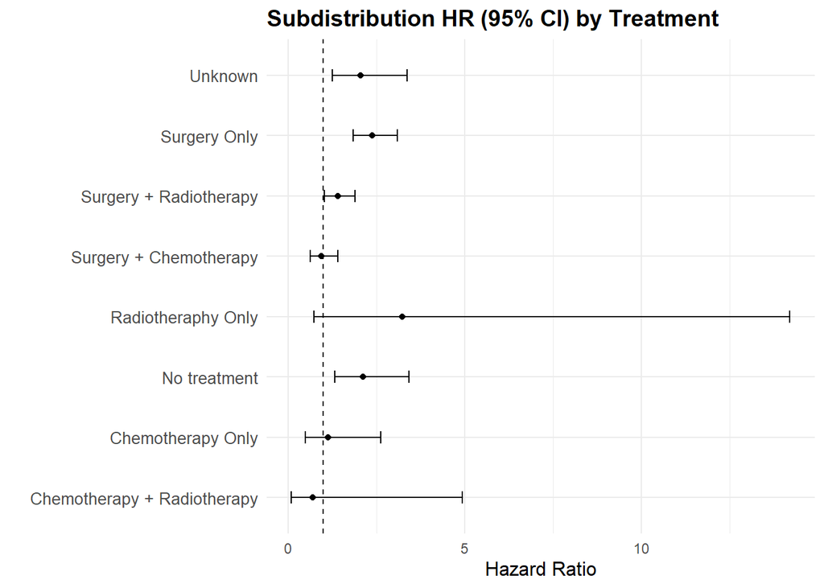

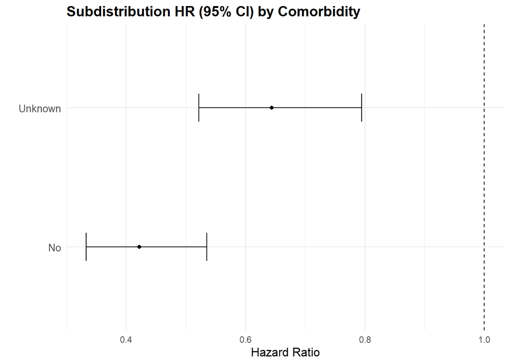